# 6. 지도학습의 회귀 분석 손실함수_평균제곱근오차사용하여 평가

### 참고

- 넷플릭스
  - 슬로건: 모든 것이 추천
  - https://medium.com/netflixtechblog/55838468f429 : 넷플릭스 추천 알고리즘 구현에 대한 기술 블로그 공개

## 1. 연구 목표

- 사용자 평점 데이터를 기반으로 사용자를 특정, 예측해 추천 시스템 구축
- 회귀 처리, 회귀 평가, 추천시스템에 대한 이해
- FastFM(third party 알고리즘 사용: 인수분해머신 기능 지원)
  - 윈도우에서는 컴파일 후 설치 불가/ 리눅스에서 설치해 진행

## 2. 데이터 수집/확보

- ml-100k.zip 파일
- 영화 정보 데이터(고객 정보/영화 정보/평점 정보)

```python
import pandas as pd
```

```python
users = pd.read_csv('../table/ml-100k/u.user', sep='|', header=None)
```

```python
users.columns = ['uid','age','m','job','zip_code']
users.tail(2)
```

|  | uid | age | m | job | zip_code |
| --- | --- | --- | --- | --- | --- |
| 941 | 942 | 48 | F | librarian | 78209 |
| 942 | 943 | 22 | M | student | 77841 |

```python
cols = ['mid','title','release_date','video_release_date','imdb_url']
movies = pd.read_csv('../table/ml-100k/u.item', sep='|', header=None, encoding='latin1', names=cols, usecols=range(5))
movies.tail(3)
```

|  | mid | title | release_date | video_release_date | imdb_url |
| --- | --- | --- | --- | --- | --- |
| 1679 | 1680 | Sliding Doors (1998) | 01-Jan-1998 | NaN | http://us.imdb.com/Title?Sliding+Doors+(1998) |
| 1680 | 1681 | You So Crazy (1994) | 01-Jan-1994 | NaN | http://us.imdb.com/M/title-exact?You%20So%20Cr... |
| 1681 | 1682 | Scream of Stone (Schrei aus Stein) (1991) | 08-Mar-1996 | NaN | http://us.imdb.com/M/title-exact?Schrei%20aus%... |

```python
movies.shape
```

```
(1682, 5)
```

```python
ratings = pd.read_csv('../table/ml-100k/u.data', sep='\t', header=None, names=['uid','mid','rating','unix_timestamp'])
ratings.head(2)
```

|  | uid | mid | rating | unix_timestamp |
| --- | --- | --- | --- | --- |
| 0 | 196 | 242 | 3 | 881250949 |
| 1 | 186 | 302 | 3 | 891717742 |

```python
# unix_timestamp는 1970년 1월 1일 00시 00분 00초부터 현재까지 경과된 시간 +09:00
# 시간 형식 변경
ratings['date'] = pd.to_datetime( ratings.unix_timestamp, unit='s' )
ratings.head(2)
```

|  | uid | mid | rating | unix_timestamp | date |
| --- | --- | --- | --- | --- | --- |
| 0 | 196 | 242 | 3 | 881250949 | 1997-12-04 15:55:49 |
| 1 | 186 | 302 | 3 | 891717742 | 1998-04-04 19:22:22 |

## 3. 데이터 준비/품질향상/전처리

```python
movies_ratings = pd.merge(movies, ratings, on='mid')
movies_ratings.shape
```

```
(100000, 9)
```

```python
movies_lens = pd.merge(movies_ratings, users)
movies_lens.head(2)
```

|  | mid | title | release_date | video_release_date | imdb_url | uid | rating | unix_timestamp | date | age | m | job | zip_code |
| --- | --- | --- | --- | --- | --- | --- | --- | --- | --- | --- | --- | --- | --- |
| 0 | 1 | Toy Story (1995) | 01-Jan-1995 | NaN | http://us.imdb.com/M/title-exact?Toy%20Story%2... | 308 | 4 | 887736532 | 1998-02-17 17:28:52 | 60 | M | retired | 95076 |
| 1 | 4 | Get Shorty (1995) | 01-Jan-1995 | NaN | http://us.imdb.com/M/title-exact?Get%20Shorty%... | 308 | 5 | 887737890 | 1998-02-17 17:51:30 | 60 | M | retired | 95076 |

- 데이터 병합 완료. 평점이나 회원을 중심으로 중복 데이터 많음
- 데이터가 크면 메모리를 많이 사용할 수도 있음

```python
movies_lens.title.value_counts()[:10]
```

```
Star Wars (1977)                 583
Contact (1997)                   509
Fargo (1996)                     508
Return of the Jedi (1983)        507
Liar Liar (1997)                 485
English Patient, The (1996)      481
Scream (1996)                    478
Toy Story (1995)                 452
Air Force One (1997)             431
Independence Day (ID4) (1996)    429
Name: title, dtype: int64
```

```python
movies_lens.title.value_counts()[-10:]
```

```
Careful (1992)                                        1
Great Day in Harlem, A (1994)                         1
Mad Dog Time (1996)                                   1
The Courtyard (1995)                                  1
Baton Rouge (1988)                                    1
Spanish Prisoner, The (1997)                          1
B. Monkey (1998)                                      1
Yankee Zulu (1994)                                    1
Death in the Garden (Mort en ce jardin, La) (1956)    1
Shopping (1994)                                       1
Name: title, dtype: int64
```

## 4. 데이터 분석(통계적,시각적)

- 제목 기준으로 데이터를 분류
- 평가의 개수, 평균 평점이 들어가있는 df
- index: title, column: 개수, 평균평점(컬럼의 레벨이 1이 넘어도 괜찮음)

```python
import numpy as np
```

```python
# groupby(컬럼): 해당 컬림이 인덱스로 이동
# agg( {컬럼:[값처리함수]} ): 컬럼에 처리함수 개수대로 설정돼 값 자동 처리
```

```python
movie_state=movies_lens.groupby('title').agg({'rating':[np.size, np.mean]})
movie_state
```

| title | rating size | rating mean |
| --- | --- | --- |
| 'Til There Was You (1997) | 9 | 2.333333 |
| 1-900 (1994) | 5 | 2.600000 |
| 101 Dalmatians (1996) | 109 | 2.908257 |
| 12 Angry Men (1957) | 125 | 4.344000 |
| 187 (1997) | 41 | 3.024390 |
| ... | ... | ... |
| Young Guns II (1990) | 44 | 2.772727 |
| Young Poisoner's Handbook, The (1995) | 41 | 3.341463 |
| Zeus and Roxanne (1997) | 6 | 2.166667 |
| unknown | 9 | 3.444444 |
| Á köldum klaka (Cold Fever) (1994) | 1 | 3.000000 |

1664 rows × 2 columns

- 평점을 받은 개수가 1개인 경우 평균에 잡음의 개입 여지 많음
- 임계값 100개

```python
limit_std_value = 100
condition = movie_state['rating']['size'] >= limit_std_value
```

```python
movie_state[condition]
```

| title | rating size | rating mean |
| --- | --- | --- |
| 101 Dalmatians (1996) | 109 | 2.908257 |
| 12 Angry Men (1957) | 125 | 4.344000 |
| 2001: A Space Odyssey (1968) | 259 | 3.969112 |
| Absolute Power (1997) | 127 | 3.370079 |
| Abyss, The (1989) | 151 | 3.589404 |
| ... | ... | ... |
| Willy Wonka and the Chocolate Factory (1971) | 326 | 3.631902 |
| Wizard of Oz, The (1939) | 246 | 4.077236 |
| Wrong Trousers, The (1993) | 118 | 4.466102 |
| Young Frankenstein (1974) | 200 | 3.945000 |
| Young Guns (1988) | 101 | 3.207921 |

338 rows × 2 columns

```python
# 정렬
tmp = movie_state[condition].sort_values(by=[('rating','mean')], ascending=False)
tmp.head()
```

| title | rating size | rating mean |
| --- | --- | --- |
| Close Shave, A (1995) | 112 | 4.491071 |
| Schindler's List (1993) | 298 | 4.466443 |
| Wrong Trousers, The (1993) | 118 | 4.466102 |
| Casablanca (1942) | 243 | 4.456790 |
| Shawshank Redemption, The (1994) | 283 | 4.445230 |

```python
# 간단한 시각화
# x축: 평점 개수 / y축: 평가 횟수
from matplotlib import pyplot as plt
%matplotlib inline
```

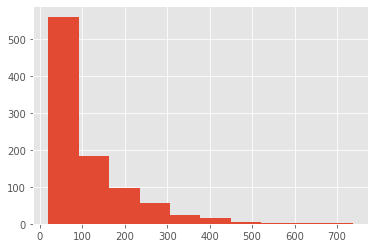

```python
plt.style.use('ggplot')
movies_lens.groupby('uid').size().sort_values(ascending=False).hist()
# 빈도가 점점 낮아짐: 롱테일분포
# '지프의 법칙'을 따른 굴곡 모양
```

```python
# 사용자별 평가 횟수, 평균
user_state = movies_lens.groupby('uid').agg({'rating':[np.size, np.mean]})
user_state.head()
```

| uid | rating size | rating mean |
| --- | --- | --- |
| 1 | 272 | 3.610294 |
| 2 | 62 | 3.709677 |
| 3 | 54 | 2.796296 |
| 4 | 24 | 4.333333 |
| 5 | 175 | 2.874286 |

```python
user_state.shape, user_state.describe()
```

```
((943, 2),            rating
              size        mean
 count  943.000000  943.000000
 mean   106.044539    3.588191
 std    100.931743    0.445233
 min     20.000000    1.491954
 25%     33.000000    3.323054
 50%     65.000000    3.620690
 75%    148.000000    3.869565
 max    737.000000    4.869565)
```

## 5. 예측모델 구축(머신러닝기반)

- 알고리즘 -> 인수분해 머신 기능을 제공하는 FastFM이라는 모듈 사용
- FastFM
  - c++로 만들어진 libFM이라는 알고리즘
  - libFM을 python으로 구성한 것이 FastFM
  - 기능 :
    - 행렬 인수 분해 일반화: 차원 축소
    - 범주형 변수를 파생변수로 변환하여 범주간의 상호 작용성을 계산
    - 특징간 영향을 주고받는 상호작용 개념을 계산
- FastFM 제공 알고리즘
  - ALS: 교대 최소 제곱법
    - 장점: 예측 시간이 빠름, SGD에 비해 하이퍼파라미터가 적다
    - 단점: 규제 처리(통제) 필요
  - SGD: 확률적 경사 하강법
    - 장점: 예측 시간이 빠름, 빅데이터를 빠르게 처리 학습 가능
    - 단점: 하이퍼파라미터가 많다, 규제 처리(통제) 필요
  - MCMC: 마르코프 연쇄 몬테카를로
    - 장점: 하이퍼파라미터가 적다
    - 단점: 학습 시간이 느리다

[리눅스 주피터 이동](http://13.125.248.156:8888)

### 가상 데이터를 이용하여 기능 확인

```python
from sklearn.feature_extraction import DictVectorizer
import numpy as np
```

```python
# DictVectorizer: 문자열만 벡터화 처리
v = DictVectorizer()
```

```python
# 더미 데이터
# 사용자 ID, 사용자가 평가한 영화 ID, 사용자의 나이
train = [
    {'uid':'1', 'mid':'5', 'age':19},
    {'uid':'2', 'mid':'43', 'age':33},
    {'uid':'3', 'mid':'20', 'age':55},
    {'uid':'4', 'mid':'10', 'age':20},
]
```

```python
X = v.fit_transform(train)
# 수치는 그대로 배치, 문자열은 벡터화(범주형으로 간주해 케이스별로 0/1로 표시)
X.toarray()
```

```
array([[19.,  0.,  0.,  0.,  1.,  1.,  0.,  0.,  0.],
       [33.,  0.,  0.,  1.,  0.,  0.,  1.,  0.,  0.],
       [55.,  0.,  1.,  0.,  0.,  0.,  0.,  1.,  0.],
       [20.,  1.,  0.,  0.,  0.,  0.,  0.,  0.,  1.]])
```

```python
# ALS를 이용해 처리
from fastFM import als
from sklearn.model_selection import learning_curve
```

```python
# user별로 부여한 평점
y = np.array( [5.0, 1.0, 2.0, 4.0] )
```

```python
# ALS를 이용해 fastFM의 회귀모델을 초기화 후 학습 진행
# 하이퍼파라미터는 임시값 부여
fm = als.FMRegression( n_iter=1000, init_stdev=0.1, rank=2, l2_reg_w=0.1, l2_reg_V=0.5)
```

```python
fm.fit(X, y)
```

```
FMRegression(init_stdev=0.1, l2_reg=0, l2_reg_V=0.5, l2_reg_w=0.1, n_iter=1000,
             random_state=123, rank=2)
```

```python
# 예측
# ex. 24살인 user가 10번 영화에 대해 부여할 평점 예측하기
# {'uid':'5', 'mid':'10', 'age':24}
fm.predict( v.transform( {'uid':'5', 'mid':'10', 'age':24} ) )
```

```
array([3.60775939])
```

```python
# 평가에 참여한 유저들의 ID만 모은 데이터셋, 영화의 ID만 모은 데이터셋
def loadData(fileName, path='../table/ml-100k/'):
    data = list() # 학습용
    y = list() # 평점
    # 중복 데이터를 제거하는 자료구조 생성
    users = set()
    movies = set()
    with open(path + fileName) as f:
        for line in f:
            uid, mid, rating, ts = line.split('\t')
            data.append({'uid':str(uid), 'mid':str(mid)})
            y.append(float(rating))
            users.add(uid)
            movies.add(mid)
    return data, np.array(y), users, movies
```

```python
dev_data, dev_y, dev_users, dev_movies = loadData('ua.base')
test_data, test_y, test_users, test_movies = loadData('ua.test')
```

```python
len(dev_users), len(dev_movies), len(test_users), len(test_movies)
```

```
(943, 1680, 943, 1129)
```

```python
len(dev_data), len(dev_y), len(test_data), len(test_y)
```

```
(90570, 90570, 9430, 9430)
```

```python
v = DictVectorizer()
```

```python
# 훈련용 데이터의 벡터화
X_dev = v.fit_transform(dev_data)
X_dev.shape
```

```
(90570, 2623)
```

```python
# 테스트용 데이터의 벡터화
X_test = v.transform(test_data)
X_test.shape
```

```
(9430, 2623)
```

```python
# 표준편차 확인: 회귀에서 평가지수 -> 평균 제곱근 오차 계산 시 평가의 잣대
np.std(dev_y), np.std(test_y)
```

```
(1.1260664426539722, 1.120180145761465)
```

```python
from sklearn.model_selection import train_test_split
```

```python
X_train, X_dev_test, y_train, y_dev_test = train_test_split(X_dev, dev_y, test_size=0.1, random_state=42)
```

```python
X_train.shape, X_dev_test.shape
```

```
((81513, 2623), (9057, 2623))
```

- 알고리즘 선택
  - mcmc
    - 학습 및 예측 수행
    - 시각화를 통해 수렴해나가는 과정
    - 테스트데이터를 이용한 성능 측정
      - 평균제곱근오차 및 손실함수 이용해 평가
    - 하이퍼파라미터 활용해 평점의 정규화 처리, 성능 평가

```python
# 평균제곱근오차함수
from sklearn.metrics import mean_squared_error
from fastFM import mcmc
```

```python
#0. 실험수치 설정
# mcmc의 하이퍼파라미터 및 실험 임계값 변수 지정
rank = 4
seed = 123
# 실험 임계값
n_iter = 300
step_size = 1 # 훈련시 사용되는 값(사용할때 확인)
```

```python
# 1.알고리즘생성
# n_iter : 샘플수 (als에서는 학습세트의 반복수 sgd에서는 단계)
# rank=인수분해의 순위
fm = mcmc.FMRegression(n_iter=0, rank=rank, random_state=seed)
```

```python
# 2. 데이터 준비(완료)
```

```python
# 3. 훈련 및 예측
fm.fit_predict(X_train, y_train, X_dev_test)
```

```
array([0., 0., 0., ..., 0., 0., 0.])
```

```python
# 4. 손실함수(:정답에 가까운 오류를 수치로 표현/정답에 가까울수록 값이 작아짐) 어떤 값으로 수렴하는지 확인
# 회귀모델에서 성능평가를 처리하는 지표 중 하나(평균제곱근오차를 통한 손실함수, 결정계수)
# 평균제곱근오차함수 값을 제곱근 처리
# 평균제곱근오차함수의 인자값(예측값, 예측에 사용한 데이터의 답)
```

```python
# 2차원 0 행렬
hyper_param = np.zeros( (n_iter-1, rank * 2 + 3), dtype=np.float64 )
hyper_param.shape, hyper_param
```

```
((299, 11), array([[0., 0., 0., ..., 0., 0., 0.],
        [0., 0., 0., ..., 0., 0., 0.],
        [0., 0., 0., ..., 0., 0., 0.],
        ...,
        [0., 0., 0., ..., 0., 0., 0.],
        [0., 0., 0., ..., 0., 0., 0.],
        [0., 0., 0., ..., 0., 0., 0.]]))
```

```python
# 구현 환경은 n_iter만큼 반복 수행
rmse_test = list()
for nr, i in enumerate(range(1, n_iter)):
    # 난수 변경 (훈련/검증 폴드 성분 변경)
    fm.random_state = i * seed
    # 학습 및 예측
    y_pred = fm.fit_predict(X_train, y_train, X_dev_test, n_more_iter=step_size)
    # 손실함수 값 획득
    loss_v = np.sqrt(mean_squared_error(y_pred, y_dev_test))
    rmse_test.append(loss_v)

    # fm.hyper_param_: 배열, 11개의 성분 가짐
#     print(fm.hyper_param_, type(fm.hyper_param_))

    hyper_param[nr,:] = fm.hyper_param_
hyper_param
```

```
array([[ 7.29936807e-02,  1.01534507e+02,  1.09545845e+02, ...,
        -2.64130136e-04, -1.52355401e-03, -1.94369678e-03],
       [ 8.36490856e-01,  1.00123392e+02,  1.05959358e+02, ...,
         6.35869726e-04, -3.12144587e-03, -2.98777035e-03],
       [ 1.02700665e+00,  3.23757929e+01,  1.01870475e+02, ...,
         1.30186941e-03, -1.33292961e-03, -3.37801855e-03],
       ...,
       [ 1.41530233e+00,  4.94956660e+00,  4.84472474e+00, ...,
        -1.59330595e-01, -2.75449109e-01,  1.48574867e-02],
       [ 1.40748074e+00,  5.36560318e+00,  5.02194975e+00, ...,
        -1.80935167e-01, -2.61153633e-01,  2.88644431e-03],
       [ 1.41138484e+00,  5.22930424e+00,  5.41863118e+00, ...,
        -1.47430605e-01, -2.64029678e-01,  1.06188403e-03]])
```

```python
# 손실함수와 fm.hyper_param_
len(rmse_test), hyper_param.shape
```

```
(299, (299, 11))
```

```python
x = np.arange(1, n_iter)
x.shape, x[:1], x[-1:]
```

```
((299,), array([1]), array([299]))
```

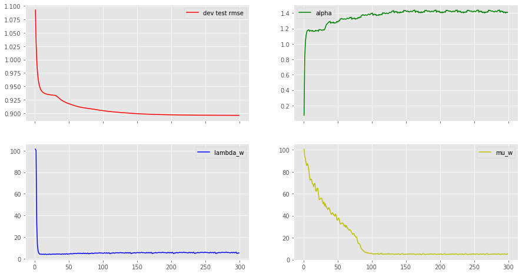

```python
# 시각화를 통해 값의 수렴 추이 확인
from matplotlib import pyplot as plt
fig, axes = plt.subplots( nrows=2, ncols=2, sharex=True, figsize=(15,8) )
# x축은 1~299, 학습 수행 횟수
axes[0,0].plot( x, rmse_test, label='dev test rmse', color='r' )
axes[0,1].plot( x, hyper_param[:, 0], label='alpha', color='g' )
axes[1,0].plot( x, hyper_param[:, 1], label='lambda_w', color='b' )
axes[1,1].plot( x, hyper_param[:, 3], label='mu_w', color='y' )

axes[0,0].legend()
axes[0,1].legend()
axes[1,0].legend()
axes[1,1].legend()
```